# Data visualization

## Paired *t*-test

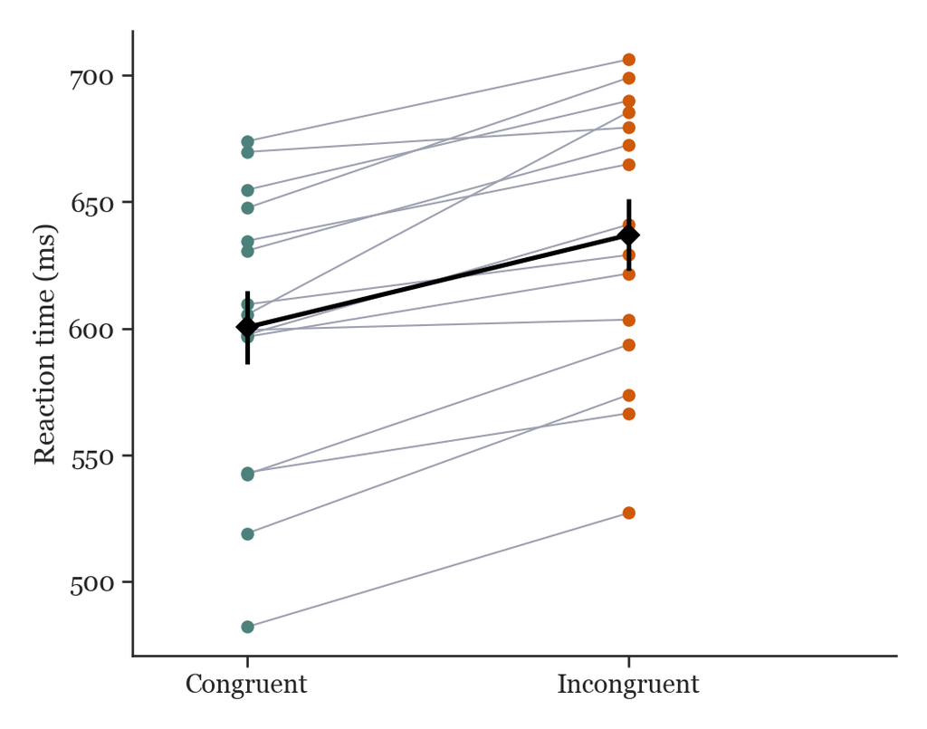

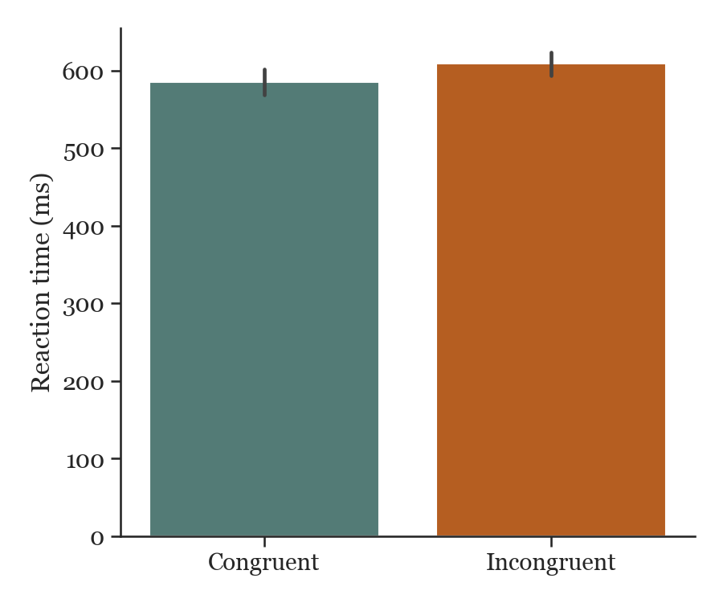

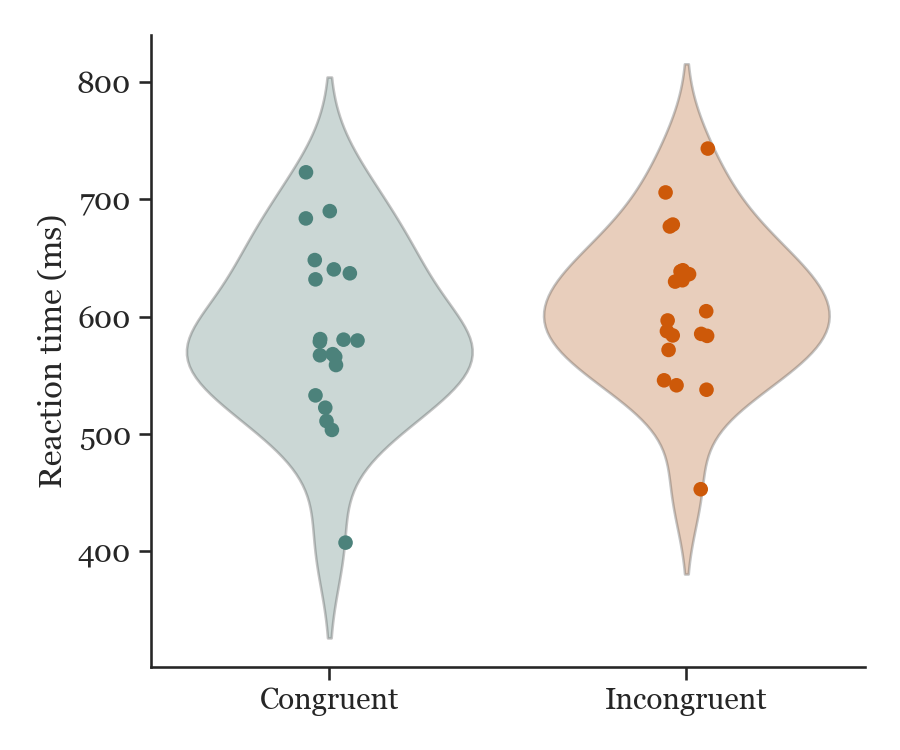

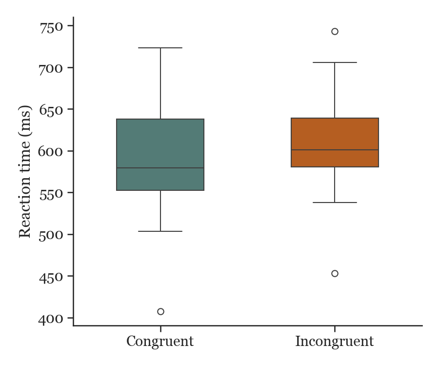

Same people, different conditions

## Independent *t*-test

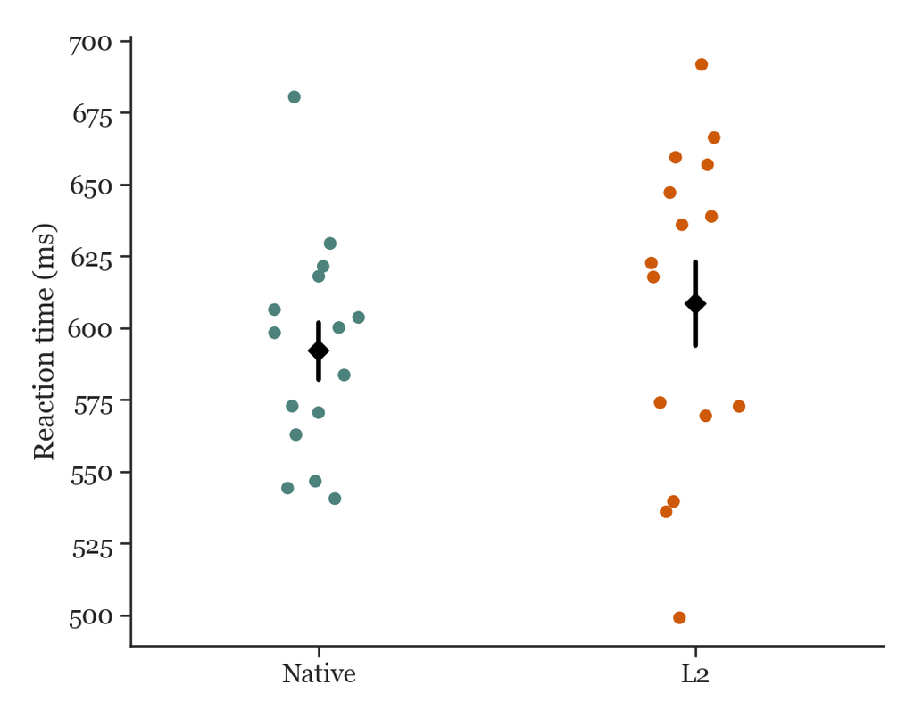

- Two groups of **different** participants
- Continuous outcome

Different people in each group.

## One-way ANOVA

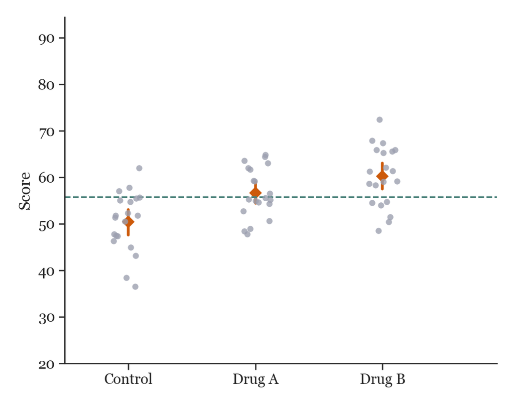

- Three or more groups (one factor)
- Continuous outcome

Do the group means differ more than the noise within groups?

## Two-way ANOVA

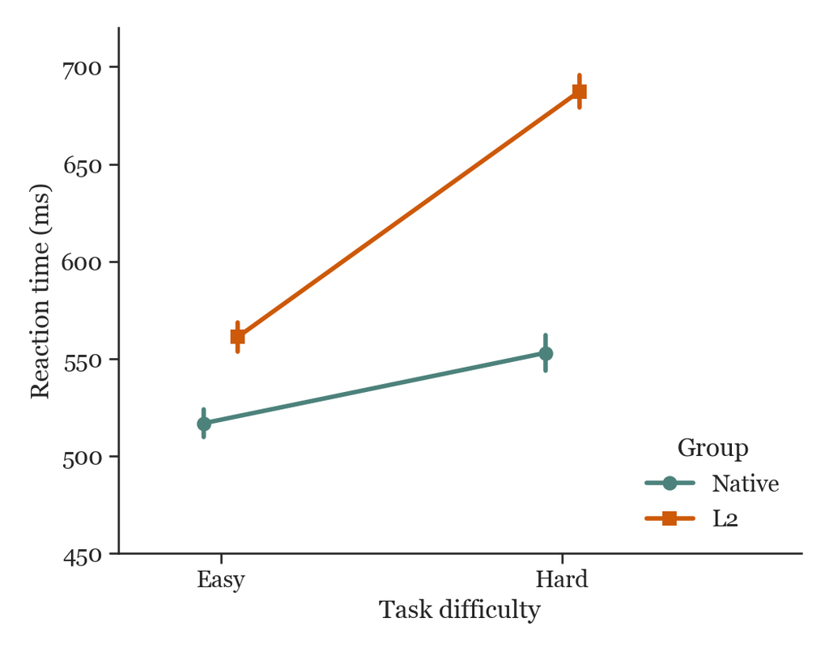

- Two factors at once
- Tests each main effect and their interaction

Two main effects + an interaction

## Linear regression

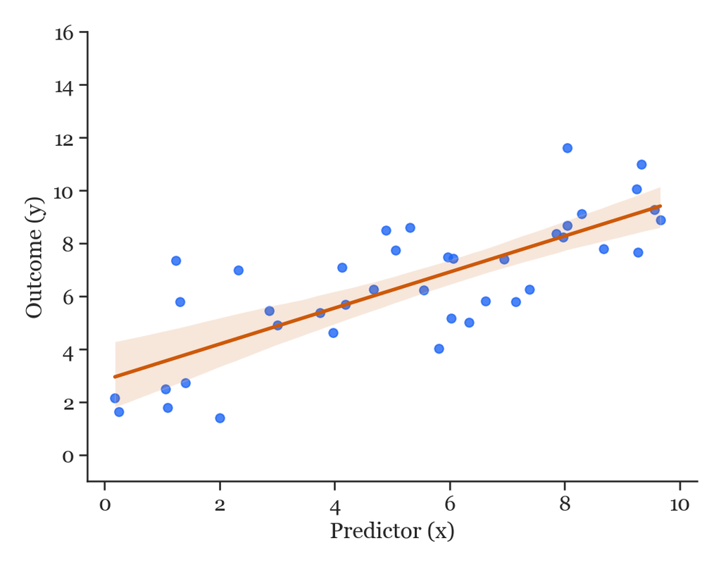

- Continuous outcome
- One or more continuous (or categorical) predictors

How much does *y* change per unit of *x*?

## Logistic regression

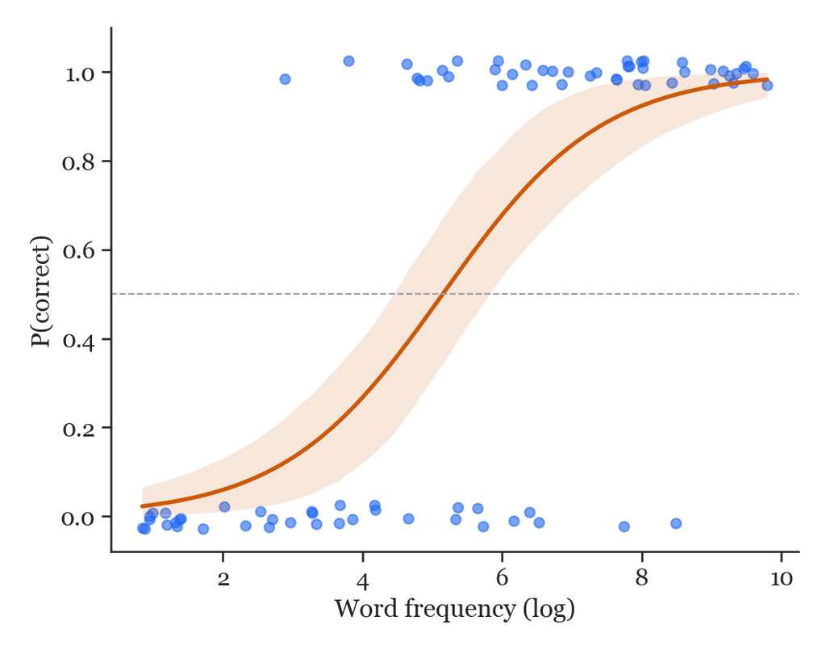

- Binary outcome (0/1, yes/no, correct/incorrect)
- One or more continuous (or categorical) predictors

How does the probability of a 1 change with *x*?

## Categorical predictors

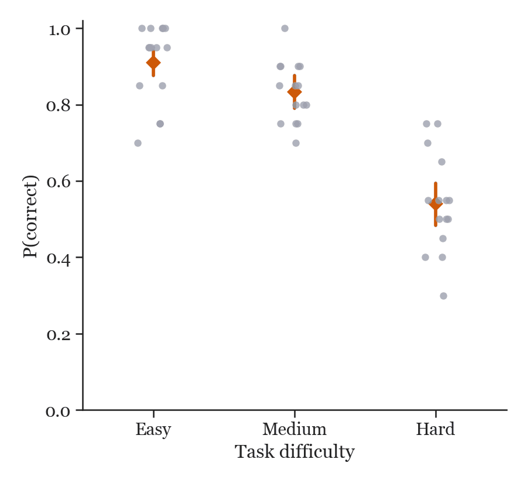

One factor (grey = one participant)

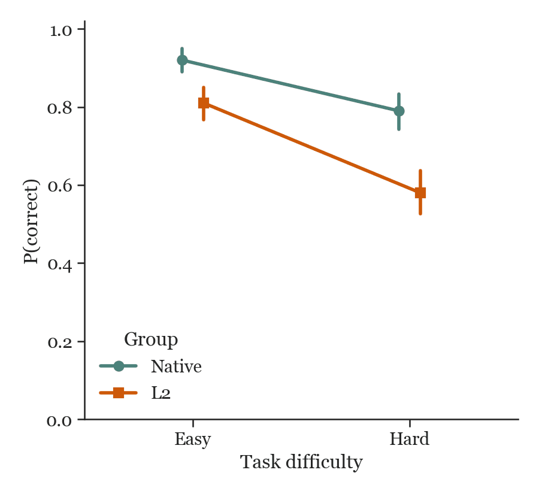

Two factors

# References

## References

Anscombe, F. J. (1973). Graphs in statistical analysis. *The American Statistician*, *27*(1), 17–21.

Danmarks Statistik. (2021). *Danmarks statistik photos*. Facebook. https://www.facebook.com/pg/danmarksstatistik/photos/

Gillespie, C., Locke, S., Davies, R., & D’Agostino McGowan, L. (2026). *datasauRus: Datasets from the Datasaurus Dozen* (Version 0.1.10) [R package]. https://github.com/jumpingrivers/datasauRus

Notopoulos, K. (2014). *The 27 worst charts of all time*. BuzzFeed News. https://www.buzzfeednews.com/article/katienotopoulos/graphs-that-lied-to-us

Tufte, E. R. (2001). *The visual display of quantitative information* (2nd ed.). Graphics Press.

Vigen, T. (2015). *Spurious correlations*. https://tylervigen.com/spurious-correlations

## Images

- **John Snow’s cholera map** — Original map by John Snow (1854). Public domain. [Wikimedia Commons](https://commons.wikimedia.org/wiki/File:Snow-cholera-map-1.jpg)